# 4.1 - One-vs-Rest, One-vs-One y softmax para el triaje de urgencias

En el capítulo 4, el equipo de Minermont quiere sugerir el **nivel de urgencia** de cada paciente que llega a urgencias, del 1 (rojo, inmediato) al 5 (azul, no urgente). Las herramientas que ya tienen, la regresión logística y las SVM, responden sí o no. Alma explica las dos formas habituales de construir un clasificador de cinco clases a partir de clasificadores binarios, **One-vs-Rest (OvR)** y **One-vs-One (OvO)**, y el equipo plantea sus puntos débiles: el desbalanceo de "Nivel 1 frente al resto", la ambigüedad cuando ningún clasificador está seguro y los empates en la votación. Carmen concluye que deberían buscar un enfoque que considere todas las clases a la vez. Para los modelos lineales, ese enfoque es la función **softmax**, la generalización de la sigmoide a varias clases.

En este cuaderno construimos los tres desde cero, con NumPy, y los comparamos con los mismos pacientes:

1. Importar las bibliotecas.
2. Los datos de triaje.
3. La pieza básica: la regresión logística binaria.
4. One-vs-Rest: cinco clasificadores.
5. La ambigüedad de One-vs-Rest.
6. One-vs-One: diez clasificadores y una votación.
7. Regresión softmax: un solo modelo para los cinco niveles.
8. Comparación: un paciente, tres respuestas.

### Paso 1: Importar las bibliotecas

Los algoritmos se escriben con NumPy. scikit-learn solo se usa para dividir los datos y, al final del paso 7, para comprobar nuestra regresión softmax con su `LogisticRegression`.

```python
import itertools
import numpy as np
import pandas as pd
import matplotlib.pyplot as plt
from sklearn.model_selection import train_test_split
from sklearn.linear_model import LogisticRegression
from sklearn.metrics import ConfusionMatrixDisplay
```

### Paso 2: Los datos de triaje

Los registros de urgencias de un hospital real son confidenciales, así que generamos **pacientes sintéticos** que se comportan como los del libro. La siguiente celda contiene el generador. No hace falta seguirlo línea a línea: lo importante es que el nivel de urgencia sale de un protocolo oculto (una puntuación de alerta temprana basada en los signos vitales, más algunas señales de alarma clínicas) y del criterio de la propia enfermera, que a veces mueve el nivel un escalón. Los modelos nunca ven esa regla: tienen que descubrirla a partir de los ejemplos.

```python
def generate_patients(n, seed):
    """Pacientes sintéticos de urgencias de Minermont: una fila por paciente, con el nivel de urgencia asignado en el triaje."""
    rng = np.random.default_rng(seed)
    age = np.clip(np.round(np.where(rng.random(n) < 0.12, rng.uniform(1, 17, n), rng.normal(52, 20, n))), 1, 97)
    male = rng.binomial(1, 0.5, n)
    s = rng.gamma(0.9, 0.55, n)                        # gravedad oculta del episodio (el modelo nunca la ve)
    infection = rng.binomial(1, 0.12 + 0.1 * (s > 1), n)
    trauma = rng.binomial(1, 0.2, n)
    chest_pain = rng.binomial(1, np.clip(0.04 + 0.0025 * age, 0, 0.35), n)
    dyspnea = rng.binomial(1, np.clip(0.06 + 0.25 * s, 0, 0.9), n)
    vomiting = rng.binomial(1, 0.12, n)
    shock = (rng.random(n) < 0.35) & (s > 1.2)
    hr = 76 + 16 * s + 12 * infection + rng.normal(0, 10, n)
    brady = (rng.random(n) < 0.08) & (s > 1.3)         # algunos pacientes graves tienen el pulso muy lento
    hr = np.where(brady, rng.normal(42, 6, n), hr)
    rr = 15 + 4.5 * s + 3 * dyspnea + rng.normal(0, 2.2, n)
    spo2 = np.clip(98.2 - 2.2 * s * (0.5 + dyspnea) + rng.normal(0, 1.1, n), 70, 100)
    sbp = np.clip(128 + 0.25 * (age - 50) + rng.normal(0, 16, n) - 28 * s * shock, 60, 230)
    temp = 36.8 + rng.normal(0, 0.35, n) + infection * rng.normal(1.6, 0.6, n)
    p_consc = np.clip(0.02 * s ** 2.2, 0, 0.9)
    consc = np.where(rng.random(n) < p_consc, rng.choice([1, 2, 3], n, p=[0.55, 0.3, 0.15]), 0)
    pain = np.clip(np.round(rng.normal(2.5 + 3.5 * trauma + 3 * chest_pain + 0.8 * s, 1.8, n)), 0, 10).astype(int)
    hr, rr, sbp = np.round(hr).astype(int), np.round(rr).astype(int), np.round(sbp).astype(int)
    temp, spo2 = np.round(temp, 1), np.round(spo2).astype(int)

    # El protocolo oculto detrás de las etiquetas, que solo usamos para generar los datos:
    # una puntuación de alerta temprana en la que un signo vital suma puntos si es demasiado bajo O demasiado alto...
    score = (np.select([rr <= 8, rr <= 11, rr <= 20, rr <= 24], [3, 1, 0, 2], 3)
             + np.select([spo2 <= 91, spo2 <= 93, spo2 <= 95], [3, 2, 1], 0)
             + np.select([sbp <= 90, sbp <= 100, sbp <= 110, sbp <= 219], [3, 2, 1, 0], 3)
             + np.select([hr <= 40, hr <= 50, hr <= 90, hr <= 110, hr <= 130], [3, 1, 0, 1, 2], 3)
             + np.where(consc > 0, 3, 0)
             + np.select([temp <= 35, temp <= 36, temp <= 38, temp <= 39], [3, 1, 0, 1], 2))
    # ...más discriminadores clínicos, del nivel menos urgente al más urgente
    level = np.full(n, 5)
    level = np.where((score >= 1) | (pain >= 4) | (trauma == 1), 4, level)
    level = np.where((score >= 4) | (pain >= 7) | (temp >= 39) | ((chest_pain == 1) & (age < 45)), 3, level)
    level = np.where((score >= 6) | ((chest_pain == 1) & (age >= 45)) | (spo2 <= 91), 2, level)
    level = np.where((score >= 9) | (consc >= 2) | (sbp <= 80), 1, level)
    # y el criterio de la propia enfermera, que a veces mueve el nivel un escalón
    level = np.clip(level + rng.choice([-1, 0, 1], n, p=[0.05, 0.9, 0.05]), 1, 5)

    return pd.DataFrame({
        'edad': age.astype(int), 'hombre': male, 'presion_sistolica': sbp, 'frec_cardiaca': hr, 'frec_respiratoria': rr,
        'spo2': spo2, 'temperatura': temp, 'consciencia': consc, 'dolor': pain, 'dolor_toracico': chest_pain,
        'disnea': dyspnea, 'traumatismo': trauma, 'vomitos': vomiting, 'nivel': level,
    })
```

| Columna | Significado |
| --- | --- |
| `edad` | Edad en años (1–97; aproximadamente uno de cada ocho pacientes es un niño) |
| `hombre` | 1 si el paciente es hombre, 0 si es mujer |
| `presion_sistolica` | Presión arterial sistólica (mmHg) |
| `frec_cardiaca` | Frecuencia cardiaca (latidos por minuto) |
| `frec_respiratoria` | Frecuencia respiratoria (respiraciones por minuto) |
| `spo2` | Saturación de oxígeno (%) |
| `temperatura` | Temperatura (°C) |
| `consciencia` | Nivel de consciencia: 0 alerta, 1 responde a la voz, 2 responde solo al dolor, 3 no responde |
| `dolor` | Dolor referido por el paciente (0–10) |
| `dolor_toracico`, `disnea`, `traumatismo`, `vomitos` | Síntomas de consulta: dolor torácico, dificultad para respirar, traumatismo, vómitos (1 = sí) |
| `nivel` | **Objetivo**: nivel de urgencia, de 1 (rojo, inmediato) a 5 (azul, no urgente) |

Usamos los mismos 4.000 pacientes y la misma división que los demás cuadernos de este capítulo. Como en el capítulo 3, las características se estandarizan con la media y la desviación típica del conjunto de entrenamiento.

```python
df = generate_patients(4000, seed=42)
feature_names = [c for c in df.columns if c != 'nivel']
level_names = ['1 Rojo', '2 Naranja', '3 Amarillo', '4 Verde', '5 Azul']
X = df[feature_names]
y = df['nivel']

X_train, X_test, y_train, y_test = train_test_split(X, y, test_size=0.25, random_state=42, stratify=y)
print(f"Entrenamiento: {len(y_train)} pacientes, prueba: {len(y_test)} pacientes\n")
print("Pacientes por nivel de urgencia:")
print(pd.DataFrame({'pacientes': y.value_counts().sort_index(),
                    'proporción': y.value_counts(normalize=True).sort_index().round(3)},).set_axis(level_names).to_string())
```

```
Entrenamiento: 3000 pacientes, prueba: 1000 pacientes

Pacientes por nivel de urgencia:
            pacientes  proporción
1 Rojo            158       0.040
2 Naranja         530       0.132
3 Amarillo        780       0.195
4 Verde          1671       0.418
5 Azul            861       0.215
```

```python
mean, std = X_train.mean(), X_train.std()
Z_train = ((X_train - mean) / std).to_numpy()
Z_test = ((X_test - mean) / std).to_numpy()
y_tr, y_te = y_train.to_numpy(), y_test.to_numpy()
levels = np.arange(1, 6)
print(f"Características: {Z_train.shape[1]}, niveles: {len(levels)}")
```

```
Características: 13, niveles: 5
```

### Paso 3: La pieza básica: la regresión logística binaria

OvR y OvO reutilizan un clasificador binario. Tomamos la regresión logística del capítulo 3: una puntuación lineal $z = \mathbf{w} \cdot \mathbf{x} + b$, la sigmoide $\sigma(z) = \frac{1}{1 + e^{-z}}$ para convertirla en una probabilidad y el descenso del gradiente sobre la pérdida logarítmica. También escribimos una pequeña función que mide, para cada nivel, la proporción de sus pacientes que el modelo asigna al nivel correcto (la **sensibilidad** o *recall* de cada clase).

```python
def sigmoid(z):
    return 1 / (1 + np.exp(-z))

def train_logistic(Z, t, learning_rate=1.0, iterations=5000):
    """Regresión logística binaria por descenso del gradiente. t vale 1 para la clase positiva y 0 para la negativa."""
    w, b = np.zeros(Z.shape[1]), 0.0
    for _ in range(iterations):
        error = sigmoid(Z @ w + b) - t
        w -= learning_rate * Z.T @ error / len(t)
        b -= learning_rate * error.mean()
    return w, b

def recall_per_level(y_true, y_pred):
    return pd.Series([np.mean(y_pred[y_true == k] == k) for k in levels], index=level_names)
```

### Paso 4: One-vs-Rest: cinco clasificadores

Como resume Marta, con cinco niveles OvR entrena cinco modelos: Nivel 1 frente a (2, 3, 4, 5), Nivel 2 frente a (1, 3, 4, 5), y así sucesivamente. Cada uno usa todos los pacientes de entrenamiento, etiquetados con 1 si pertenecen a su nivel y con 0 si no. Para predecir, los cinco clasificadores puntúan al paciente y gana el nivel cuyo clasificador da la puntuación más alta.

```python
ovr_models = {}
for k in levels:
    t = (y_tr == k).astype(float)                          # nivel k = 1, cualquier otro nivel = 0
    ovr_models[k] = train_logistic(Z_train, t)
    print(f"{level_names[k - 1]:<10} frente al resto: {t.mean():5.1%} de los {len(t)} pacientes de entrenamiento son positivos")

ovr_scores = np.column_stack([sigmoid(Z_test @ w + b) for w, b in ovr_models.values()])
ovr_pred = levels[ovr_scores.argmax(axis=1)]                 # el nivel cuyo clasificador está más seguro

print(f"\nExactitud de OvR en el conjunto de prueba: {np.mean(ovr_pred == y_te):.3f}")
print("Sensibilidad por nivel:")
print(recall_per_level(y_te, ovr_pred).round(3).to_string())
```

```
1 Rojo     frente al resto:  3.9% de los 3000 pacientes de entrenamiento son positivos
```

```
2 Naranja  frente al resto: 13.3% de los 3000 pacientes de entrenamiento son positivos
```

```
3 Amarillo frente al resto: 19.5% de los 3000 pacientes de entrenamiento son positivos
```

```
4 Verde    frente al resto: 41.8% de los 3000 pacientes de entrenamiento son positivos
```

```
5 Azul     frente al resto: 21.5% de los 3000 pacientes de entrenamiento son positivos

Exactitud de OvR en el conjunto de prueba: 0.625
Sensibilidad por nivel:
1 Rojo        0.700
2 Naranja     0.735
3 Amarillo    0.221
4 Verde       0.813
5 Azul        0.544
```

La aguja en el pajar de Víctor está ahí: solo el 3,9% de los pacientes son positivos para "Nivel 1 frente al resto". Aun así, OvR encuentra el 0,700 de los pacientes rojos. La verdadera víctima es el nivel 3: solo el 0,221 de los pacientes amarillos reciben su nivel. Una puntuación lineal puede separar "más urgente" de "menos urgente", pero "Nivel 3 frente al resto" le pide separar una franja del medio de pacientes situados a ambos lados, más urgentes (niveles 1 y 2) y menos urgentes (4 y 5). El clasificador del nivel 3 rara vez gana, y la matriz de confusión del paso 8 muestra adónde van sus pacientes: 108 de los 195 pacientes amarillos del conjunto de prueba acaban en verde. La exactitud global es 0,625.

### Paso 5: La ambigüedad de One-vs-Rest

La duda de Javier: "¿Qué hacemos si ningún clasificador da una confianza alta, o si dos la dan muy similar?". Los cinco clasificadores se entrenan por separado, así que nada hace que sus puntuaciones sumen 1 ni que sean comparables entre sí. Miramos las puntuaciones de los cinco primeros pacientes de prueba y contamos los casos dudosos.

```python
first = pd.DataFrame(ovr_scores[:5], columns=level_names).round(3)
first['suma'] = ovr_scores[:5].sum(axis=1).round(3)
first['nivel real'] = y_te[:5]
print(first.to_string(), "\n")

best, second = np.sort(ovr_scores, axis=1)[:, ::-1][:, :2].T
print(f"Suma de las cinco puntuaciones: de {ovr_scores.sum(axis=1).min():.3f} a {ovr_scores.sum(axis=1).max():.3f}")
print(f"Pacientes para los que ningún clasificador llega a 0,5: {np.sum(best < 0.5)} de {len(y_te)}")
print(f"Pacientes cuyas dos puntuaciones más altas se diferencian en menos de 0,1: {np.sum(best - second < 0.1)}")
print("Puntuación más alta que da cada clasificador a algún paciente de prueba:")
print(pd.Series(ovr_scores.max(axis=0), index=level_names).round(3).to_string())
```

```
   1 Rojo  2 Naranja  3 Amarillo  4 Verde  5 Azul   suma  nivel real
0   0.002      0.222       0.028    0.224   0.780  1.256           2
1   0.015      0.005       0.059    0.459   0.648  1.186           4
2   0.005      0.011       0.074    0.506   0.502  1.098           5
3   0.112      0.799       0.166    0.011   0.000  1.088           2
4   0.004      0.006       0.243    0.739   0.037  1.028           3

Suma de las cinco puntuaciones: de 0.352 a 2.417
Pacientes para los que ningún clasificador llega a 0,5: 338 de 1000
Pacientes cuyas dos puntuaciones más altas se diferencian en menos de 0,1: 211
Puntuación más alta que da cada clasificador a algún paciente de prueba:
1 Rojo        1.000
2 Naranja     0.996
3 Amarillo    0.886
4 Verde       0.801
5 Azul        0.963
```

Las cinco puntuaciones de un paciente suman cualquier cosa entre 0,352 y 2,417: son cinco opiniones separadas, no una distribución de probabilidad. Para 338 de los 1.000 pacientes de prueba ningún clasificador llega a 0,5, y para 211 las dos puntuaciones más altas se diferencian en menos de 0,1, como el tercer paciente de la tabla, 0,506 para verde y 0,502 para azul (el nivel real es azul). Los niveles del medio son además los menos seguros: la puntuación más alta que da el clasificador del nivel 3 a algún paciente es 0,886, y el del nivel 4, 0,801, mientras que los clasificadores rojo y naranja llegan a 1,000 y 0,996. La puntuación del quinto paciente, que es amarillo, es 0,243 frente a 0,739 para verde. Es lo que el libro llama una calibración inconsistente entre clasificadores, y la razón por la que a Javier no le convence: en triaje la respuesta tiene que ser clara.

### Paso 6: One-vs-One: diez clasificadores y una votación

OvO entrena un clasificador para cada par de niveles, $\frac{K(K-1)}{2} = \frac{5 \times 4}{2} = 10$, cada uno solo con los pacientes de sus dos niveles. Para predecir, cada clasificador vota por uno de sus dos niveles y gana el nivel con más votos. Luis pregunta qué ocurre si hay un empate. La regla del libro para la regresión logística: elegir, entre los niveles empatados, el que tenga la mayor confianza media en sus victorias.

```python
ovo_models = {}
for i, j in itertools.combinations(levels, 2):
    in_pair = (y_tr == i) | (y_tr == j)                    # solo los pacientes de estos dos niveles
    ovo_models[(i, j)] = train_logistic(Z_train[in_pair], (y_tr[in_pair] == i).astype(float))
    smaller = min(np.sum(y_tr == i), np.sum(y_tr == j)) / in_pair.sum()
    print(f"Nivel {i} frente a nivel {j}: {in_pair.sum():>4} pacientes, el nivel menos frecuente es el {smaller:5.1%}")

votes = np.zeros((len(y_te), 5))
confidence = np.zeros((len(y_te), 5))                        # confianza sumada de las victorias de cada nivel
for (i, j), (w, b) in ovo_models.items():
    p = sigmoid(Z_test @ w + b)                              # probabilidad del nivel i frente al nivel j
    i_wins = p >= 0.5
    votes[i_wins, i - 1] += 1
    votes[~i_wins, j - 1] += 1
    confidence[i_wins, i - 1] += p[i_wins]
    confidence[~i_wins, j - 1] += 1 - p[~i_wins]

most_votes = votes == votes.max(axis=1, keepdims=True)
tied = most_votes.sum(axis=1) > 1
average_confidence = confidence / np.maximum(votes, 1)
ovo_pred = levels[np.where(most_votes, average_confidence, -1).argmax(axis=1)]   # regla de desempate del libro

print(f"\nPacientes con un empate en el máximo de votos: {tied.sum()} de {len(y_te)}")
print(f"Exactitud de OvO en el conjunto de prueba: {np.mean(ovo_pred == y_te):.3f}")
print("Sensibilidad por nivel:")
print(recall_per_level(y_te, ovo_pred).round(3).to_string())
```

```
Nivel 1 frente a nivel 2:  516 pacientes, el nivel menos frecuente es el 22.9%
Nivel 1 frente a nivel 3:  703 pacientes, el nivel menos frecuente es el 16.8%
```

```
Nivel 1 frente a nivel 4: 1371 pacientes, el nivel menos frecuente es el  8.6%
```

```
Nivel 1 frente a nivel 5:  764 pacientes, el nivel menos frecuente es el 15.4%
Nivel 2 frente a nivel 3:  983 pacientes, el nivel menos frecuente es el 40.5%
```

```
Nivel 2 frente a nivel 4: 1651 pacientes, el nivel menos frecuente es el 24.1%
Nivel 2 frente a nivel 5: 1044 pacientes, el nivel menos frecuente es el 38.1%
```

```
Nivel 3 frente a nivel 4: 1838 pacientes, el nivel menos frecuente es el 31.8%
Nivel 3 frente a nivel 5: 1231 pacientes, el nivel menos frecuente es el 47.5%
```

```
Nivel 4 frente a nivel 5: 1899 pacientes, el nivel menos frecuente es el 34.0%

Pacientes con un empate en el máximo de votos: 5 de 1000
Exactitud de OvO en el conjunto de prueba: 0.660
Sensibilidad por nivel:
1 Rojo        0.725
2 Naranja     0.720
3 Amarillo    0.472
4 Verde       0.763
5 Azul        0.581
```

Cada par usa menos pacientes, de 516 a 1.899, y la mayoría de los pares están más equilibrados que "Nivel 1 frente al resto": en "Nivel 1 frente a nivel 2" los pacientes rojos son el 22,9% en lugar del 3,9%. El par más desbalanceado, 1 frente a 4, todavía tiene un 8,6%. Los empates son raros, 5 de los 1.000 pacientes de prueba, así que aquí la pregunta de Luis tiene una respuesta sencilla. OvO sube la exactitud a 0,660 y, sobre todo, la sensibilidad del nivel 3 de 0,221 a 0,472: "Nivel 2 frente a nivel 3" y "Nivel 3 frente a nivel 4" son problemas que una puntuación lineal sí puede resolver, porque cada uno separa dos niveles vecinos.

### Paso 7: Regresión softmax: un solo modelo para los cinco niveles

En lugar de cinco o diez clasificadores separados, un único modelo lineal da a cada paciente cinco puntuaciones a la vez, $z_k = \mathbf{w}_k \cdot \mathbf{x} + b_k$, una por nivel, y la función **softmax** las convierte en una distribución de probabilidad:

$$\text{Softmax}(z_k) = \frac{e^{z_k}}{\sum_{j=1}^{5} e^{z_j}}$$

Las cinco probabilidades son positivas y suman 1, y los niveles compiten entre sí: subir una puntuación baja la probabilidad de todos los demás. Se entrena, como la capa de salida de las redes neuronales del libro, minimizando la **entropía cruzada categórica**, el logaritmo negativo de la probabilidad asignada al nivel real:

$$L = -\frac{1}{m} \sum_{i=1}^{m} \log \hat{y}_{i,\,\text{nivel real}}$$

Su gradiente respecto a las puntuaciones tiene la misma forma que en el caso binario: probabilidad menos etiqueta, $\hat{\mathbf{y}} - \mathbf{y}$, donde $\mathbf{y}$ es el nivel real escrito como un vector *one-hot* (el nivel 3 es $[0, 0, 1, 0, 0]$). Con dos niveles, la regresión softmax es exactamente la regresión logística.

```
Entropía cruzada: 1.6094 al principio, 0.79455 tras 5000 iteraciones
Suma de las cinco probabilidades: de 1.000000 a 1.000000
Exactitud de softmax en el conjunto de prueba: 0.657
Sensibilidad por nivel:
1 Rojo        0.750
2 Naranja     0.735
3 Amarillo    0.446
4 Verde       0.768
5 Azul        0.567

scikit-learn: entropía cruzada 0.79452, exactitud 0.657, mayor diferencia en una probabilidad 0.0142
```

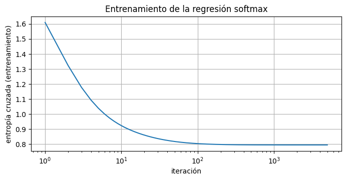

```python
def softmax(scores):
    scores = scores - scores.max(axis=1, keepdims=True)      # las mismas probabilidades, sin desbordar exp
    e = np.exp(scores)
    return e / e.sum(axis=1, keepdims=True)

def cross_entropy(P, y):
    return -np.mean(np.log(P[np.arange(len(y)), y - 1]))

Y_train = np.eye(5)[y_tr - 1]                                # one-hot: nivel 3 -> [0, 0, 1, 0, 0]
W, b = np.zeros((Z_train.shape[1], 5)), np.zeros(5)          # una columna de pesos por nivel
history = []
for iteration in range(5000):
    P = softmax(Z_train @ W + b)
    error = P - Y_train                                      # gradiente de la entropía cruzada respecto a las puntuaciones
    W -= 1.0 * Z_train.T @ error / len(y_tr)
    b -= 1.0 * error.mean(axis=0)
    history.append(cross_entropy(P, y_tr))

softmax_probs = softmax(Z_test @ W + b)
softmax_pred = levels[softmax_probs.argmax(axis=1)]
print(f"Entropía cruzada: {history[0]:.4f} al principio, {history[-1]:.5f} tras {len(history)} iteraciones")
print(f"Suma de las cinco probabilidades: de {softmax_probs.sum(axis=1).min():.6f} a {softmax_probs.sum(axis=1).max():.6f}")
print(f"Exactitud de softmax en el conjunto de prueba: {np.mean(softmax_pred == y_te):.3f}")
print("Sensibilidad por nivel:")
print(recall_per_level(y_te, softmax_pred).round(3).to_string())

# Comprobación: LogisticRegression de scikit-learn usa softmax con varias clases (C muy grande = sin regularización)
reference = LogisticRegression(C=1e6, max_iter=5000).fit(Z_train, y_tr)
print(f"\nscikit-learn: entropía cruzada {cross_entropy(reference.predict_proba(Z_train), y_tr):.5f}, "
      f"exactitud {reference.score(Z_test, y_te):.3f}, "
      f"mayor diferencia en una probabilidad {np.abs(reference.predict_proba(Z_test) - softmax_probs).max():.4f}")

plt.figure(figsize=(8, 3.5))
plt.plot(np.arange(1, len(history) + 1), history)
plt.xscale('log'); plt.xlabel('iteración'); plt.ylabel('entropía cruzada (entrenamiento)'); plt.grid(True)
plt.title('Entrenamiento de la regresión softmax'); plt.show()
```

La entropía cruzada empieza en 1,6094, que es $\ln 5$: con todos los pesos a cero, el modelo da 0,2 a cada nivel. Baja hasta 0,79455. Las cinco probabilidades de cada paciente de prueba suman exactamente 1. Con un solo modelo, softmax llega a una exactitud de 0,657, cerca del 0,660 de OvO, y a una sensibilidad del nivel 3 de 0,446. `LogisticRegression` de scikit-learn, que también usa softmax cuando hay varias clases, llega a una entropía cruzada de 0,79452 y a la misma exactitud, 0,657. Sus probabilidades y las nuestras se diferencian como mucho en 0,0142, porque nuestro descenso del gradiente se detiene justo antes del mínimo.

### Paso 8: Comparación: un paciente, tres respuestas

Primero, las tres estrategias una junto a otra, con su número de clasificadores y de parámetros (13 pesos y un sesgo por cada puntuación lineal), y sus matrices de confusión en el conjunto de prueba:

```
             clasificadores  parámetros  exactitud  error de 2+ niveles  sens. 1 Rojo  sens. 2 Naranja  sens. 3 Amarillo  sens. 4 Verde  sens. 5 Azul
One-vs-Rest               5          70      0.625                   30         0.700            0.735             0.221          0.813         0.544
One-vs-One               10         140      0.660                   18         0.725            0.720             0.472          0.763         0.581
Softmax                   1          70      0.657                   18         0.750            0.735             0.446          0.768         0.567
```

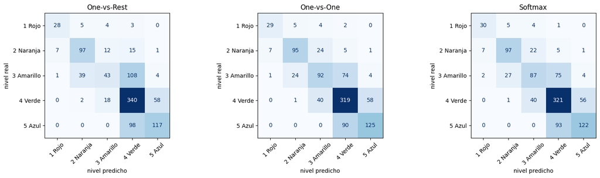

```python
n_params = Z_train.shape[1] + 1
summary = pd.DataFrame({
    'clasificadores': [len(ovr_models), len(ovo_models), 1],
    'parámetros': [len(ovr_models) * n_params, len(ovo_models) * n_params, W.size + b.size],
    'exactitud': [np.mean(p == y_te) for p in (ovr_pred, ovo_pred, softmax_pred)],
    'error de 2+ niveles': [np.sum(np.abs(p - y_te) >= 2) for p in (ovr_pred, ovo_pred, softmax_pred)],
}, index=['One-vs-Rest', 'One-vs-One', 'Softmax'])
recalls = pd.DataFrame([recall_per_level(y_te, p) for p in (ovr_pred, ovo_pred, softmax_pred)], index=summary.index)
print(pd.concat([summary, recalls.add_prefix('sens. ')], axis=1).round(3).to_string())

fig, axes = plt.subplots(1, 3, figsize=(16, 4.5))
for ax, (name, pred) in zip(axes, [('One-vs-Rest', ovr_pred), ('One-vs-One', ovo_pred), ('Softmax', softmax_pred)]):
    ConfusionMatrixDisplay.from_predictions(y_te, pred, display_labels=level_names, ax=ax, colorbar=False, cmap='Blues')
    ax.set_title(name); ax.set_xlabel('nivel predicho'); ax.set_ylabel('nivel real')
    ax.tick_params(axis='x', labelrotation=45)
plt.tight_layout(); plt.show()
```

OvO y softmax están prácticamente empatados, 0,660 y 0,657, y los dos por delante de OvR, 0,625, que pierde a los pacientes amarillos. OvO necesita 10 clasificadores y 140 parámetros, el doble que softmax, que hace el mismo trabajo con un modelo y 70. La mayoría de los errores son de un nivel: OvO y softmax cometen 18 errores de dos niveles o más en 1.000 pacientes, y OvR 30. La diagonal flojea entre niveles vecinos, el 3 y el 4, y el 4 y el 5, donde una puntuación lineal lo tiene más difícil.

Por último, el primer paciente de prueba para el que ningún clasificador OvR llega a 0,5, y lo que responde cada estrategia:

```python
patient = np.flatnonzero(best < 0.5)[0]
print(X_test.iloc[patient].to_string())
print(f"Nivel real: {y_te[patient]}\n")
print(pd.DataFrame({'puntuación OvR': ovr_scores[patient], 'votos OvO': votes[patient].astype(int),
                    'probabilidad softmax': softmax_probs[patient]}, index=level_names).round(3).to_string())
print(f"\nPredicción: OvR {ovr_pred[patient]}, OvO {ovo_pred[patient]}, softmax {softmax_pred[patient]}")
```

```
edad                  52.0
hombre                 0.0
presion_sistolica    117.0
frec_cardiaca         71.0
frec_respiratoria     16.0
spo2                  97.0
temperatura           37.2
consciencia            0.0
dolor                  2.0
dolor_toracico         0.0
disnea                 0.0
traumatismo            0.0
vomitos                0.0
Nivel real: 5

            puntuación OvR  votos OvO  probabilidad softmax
1 Rojo               0.010          0                 0.002
2 Naranja            0.018          1                 0.006
3 Amarillo           0.069          2                 0.042
4 Verde              0.429          3                 0.477
5 Azul               0.457          4                 0.474

Predicción: OvR 5, OvO 5, softmax 4
```

Una mujer de 52 años con signos vitales normales, dolor 2 y sin síntomas: su nivel real es el 5. OvR le da 0,429 para verde y 0,457 para azul, ninguno por encima de 0,5, y elige azul. OvO da al azul sus 4 votos y también elige azul. Softmax da 0,477 a verde y 0,474 a azul y elige verde, esta vez equivocándose. Los tres dudan entre los mismos dos niveles; la diferencia está en cómo lo muestran. Las probabilidades de softmax lo dicen con claridad: casi toda la probabilidad se reparte en dos mitades iguales entre verde y azul. Para un paciente en la frontera, esa es la respuesta honesta, y la útil para una enfermera de triaje: un caso para revisar más que un nivel claro.

### Conclusión

- **One-vs-Rest** construye un clasificador de $K$ clases a partir de $K$ clasificadores binarios. Es sencillo, pero cada clasificador se enfrenta a un problema desbalanceado, sus puntuaciones no suman 1 y una clase situada entre las demás puede quedar aplastada.
- **One-vs-One** entrena $K(K-1)/2$ clasificadores con pares más pequeños y más equilibrados, y los deja votar. Aquí necesita el doble de parámetros, y una regla para los empates.
- La **regresión softmax** considera todas las clases a la vez, como quería Carmen: un solo modelo, probabilidades que suman 1 y la entropía cruzada como coste. Es la versión multiclase de la regresión logística, y es lo que hace la capa de salida de una red neuronal.
- Los tres son lineales, y el protocolo de triaje no lo es: un signo vital suma puntos cuando es demasiado bajo o demasiado alto. Por eso el equipo pasó a algoritmos multiclase por naturaleza y no lineales, como los árboles de decisión y los bosques aleatorios, que construyen los siguientes cuadernos de este capítulo.